# datalab-vis01_v3

# Lab 03

## Author:Ajinkya Shinde

```r
library(dplyr)
library(tidyverse)
anim <- read_csv(here::here("data", "animal_sounds_summary.csv"))
anim
```

```
## # A tibble: 33 x 7
##      age sound      kids_produce kids_understand kids_respond prop_produce
##    <int> <chr>             <int>           <int>        <int>        <dbl>
##  1     8 cockadood~            1               3           35       0.0286
##  2     8 meow                  0              10           35       0.
##  3     8 woof woof             3              12           35       0.0857
##  4     9 cockadood~            0               2           91       0.
##  5     9 meow                  2              21           93       0.0215
##  6     9 woof woof             2              22           93       0.0215
##  7    10 cockadood~            0               9          139       0.
##  8    10 meow                  5              41          145       0.0345
##  9    10 woof woof             4              40          143       0.0280
## 10    11 cockadood~            0               4           94       0.
## # ... with 23 more rows, and 1 more variable: prop_understand <dbl>
```

- How many variables?
  - Which variables are continuous?
  - Which ones are categorical or ordinal?

```r
glimpse(anim)
```

```
## Observations: 33
## Variables: 7
## $ age             <int> 8, 8, 8, 9, 9, 9, 10, 10, 10, 11, 11, 11, 12, ...
## $ sound           <chr> "cockadoodledoo", "meow", "woof woof", "cockad...
## $ kids_produce    <int> 1, 0, 3, 0, 2, 2, 0, 5, 4, 0, 5, 12, 0, 12, 28...
## $ kids_understand <int> 3, 10, 12, 2, 21, 22, 9, 41, 40, 4, 36, 32, 16...
## $ kids_respond    <int> 35, 35, 35, 91, 93, 93, 139, 145, 143, 94, 94,...
## $ prop_produce    <dbl> 0.02857143, 0.00000000, 0.08571429, 0.00000000...
## $ prop_understand <dbl> 0.08571429, 0.28571429, 0.34285714, 0.02197802...
```

*7 variables. The continuous variables are age,kids_produce,kids_understand,kids_respond,prop_produce,prop_understand

The catergorical/ordinal variables are sound*

- How many total kids do we have data for?

```r
anim %>% tally(kids_respond)
```

```
## # A tibble: 1 x 1
##       n
##   <int>
## 1  7226
```

- How many ages (in months)?

```r
count(distinct(anim,age))
```

```
## # A tibble: 1 x 1
##       n
##   <int>
## 1    11
```

- How many kids per age?

```r
anim %>% select(age,kids_respond) %>% group_by(age) %>% summarize(grp_by_age=sum(kids_respond))
```

```
## # A tibble: 11 x 2
##      age grp_by_age
##    <int>      <int>
##  1     8        105
##  2     9        277
##  3    10        427
##  4    11        282
##  5    12        423
##  6    13       2305
##  7    14        376
##  8    15        352
##  9    16       2160
## 10    17        267
## 11    18        252
```

- How many types of animal sounds? What are they?

```r
count(distinct(anim,sound))#Types of animal sounds
```

```
## # A tibble: 1 x 1
##       n
##   <int>
## 1     3
```

```r
distinct(anim,sound)#Animal sounds kids can produce/understand
```

```
## # A tibble: 3 x 1
##   sound
##   <chr>
## 1 cockadoodledoo
## 2 meow
## 3 woof woof
```

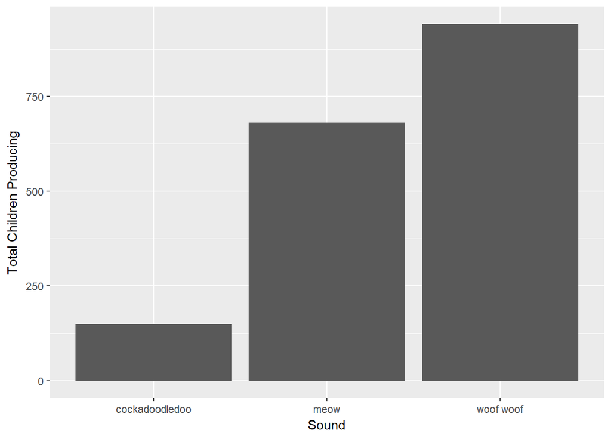

```r
anim1<-anim %>%
  group_by(sound) %>%
    summarize(kids_produce_sum=sum(kids_produce))
ggplot(anim1,aes(x=sound,y=kids_produce_sum)) + geom_col() +
  labs(x="Sound",y="Total Children Producing")
```

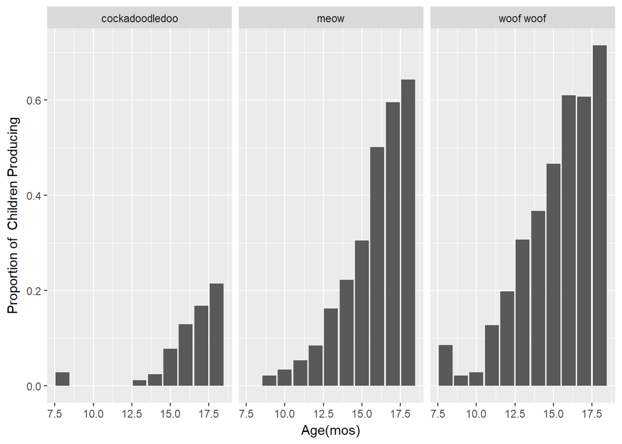

```r
ggplot(anim,aes(x=age,y=prop_produce)) + geom_col() +
  labs(x="Age(mos)",y="Proportion of  Children Producing") + facet_wrap(~sound)
```

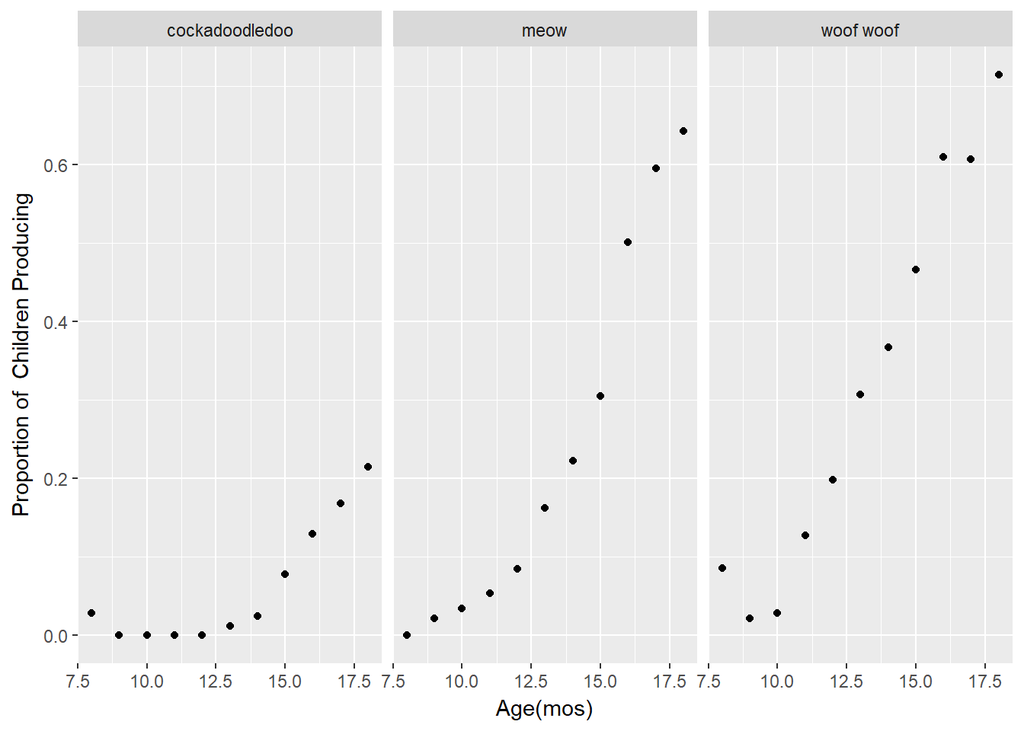

```r
ggplot(anim,aes(x=age,y=prop_produce)) + geom_point() +
  labs(x="Age(mos)",y="Proportion of  Children Producing") + facet_wrap(~sound)
```

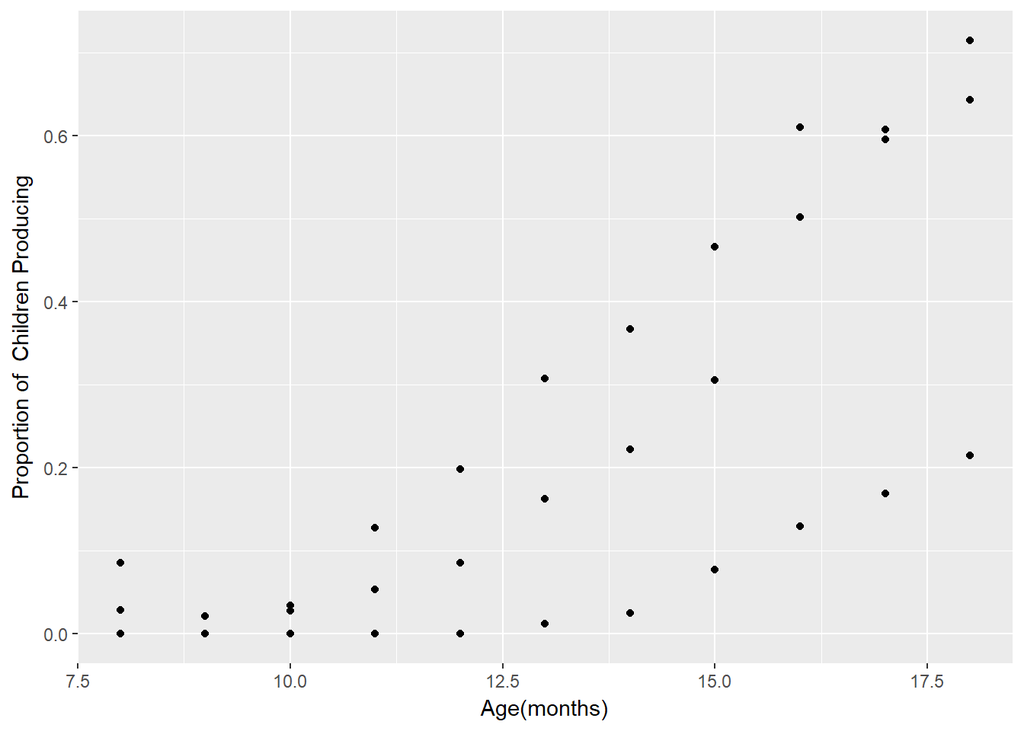

```r
ggplot(anim,aes(x=age,y=prop_produce),size=2) + geom_point() +
  labs(x="Age(months)",y="Proportion of  Children Producing")
```

*Challenge#2*

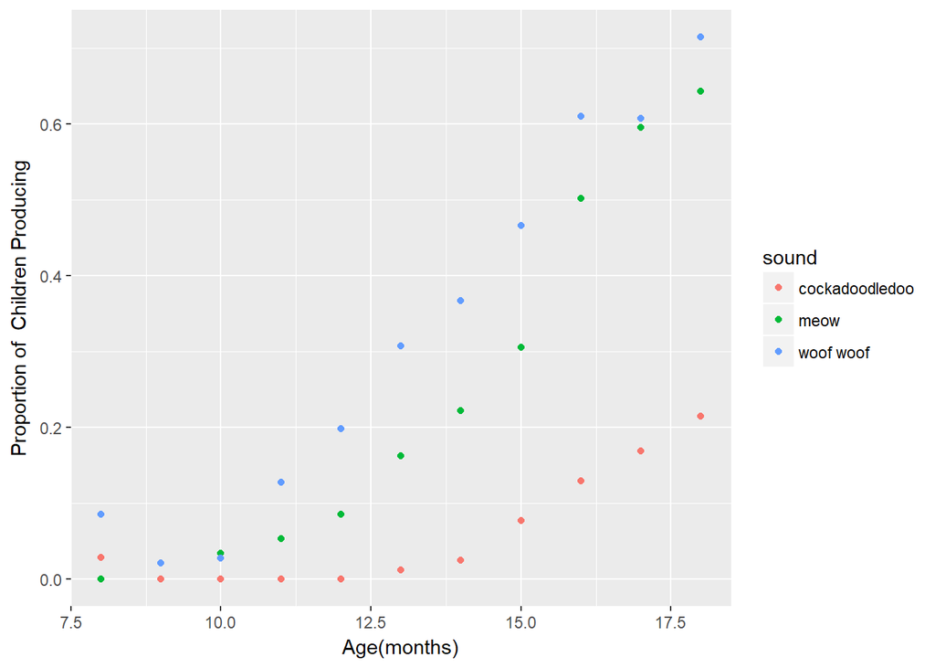

```r
ggplot(anim,aes(x=age,y=prop_produce,color=sound),size=2) + geom_point() +
  labs(x="Age(months)",y="Proportion of  Children Producing")
```

*Challenge#3*

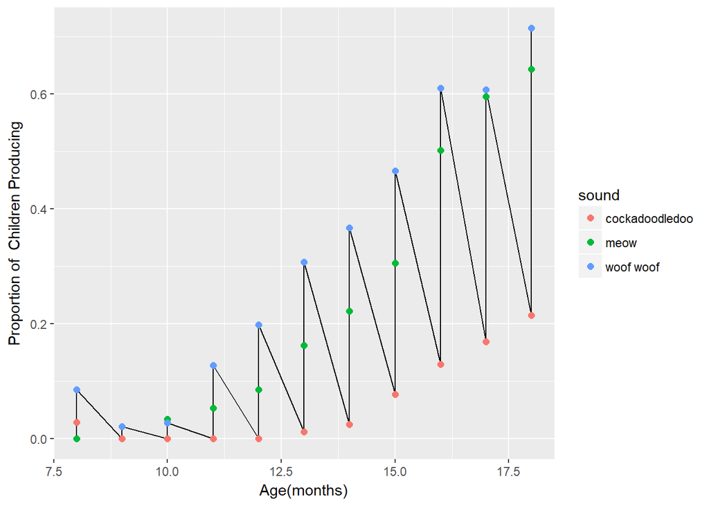

```r
ggplot(anim,aes(x=age,y=prop_produce))  +geom_line()+ geom_point(aes(color=sound),size=2)+
  labs(x="Age(months)",y="Proportion of  Children Producing")
```

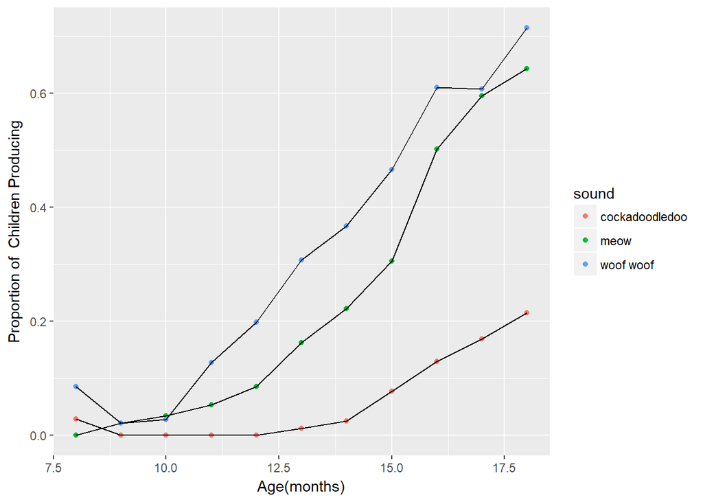

```r
ggplot(anim,aes(x=age,y=prop_produce),size=2)+ geom_point(aes(color=sound))+
  geom_line(aes(group=sound))+
  labs(x="Age(months)",y="Proportion of  Children Producing")
```

*Challenge#4*

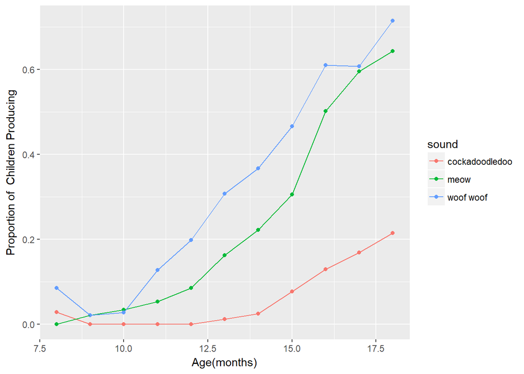

```r
ggplot(anim,aes(x=age,y=prop_produce,color=sound),size=2)+ geom_point()+
  geom_line(aes(group=sound))+
  labs(x="Age(months)",y="Proportion of  Children Producing")
```

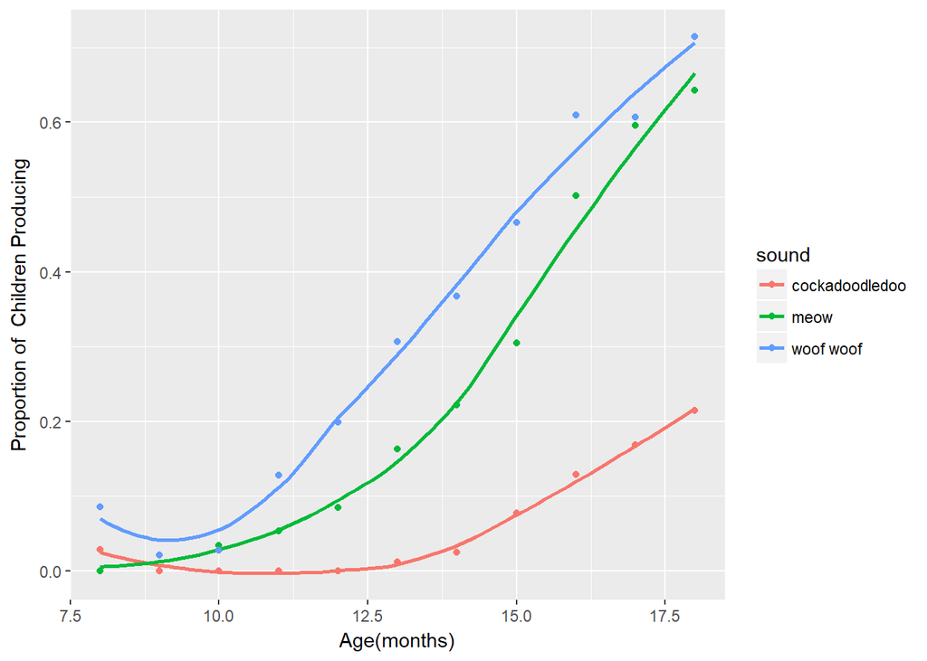

```r
ggplot(anim,aes(x=age,y=prop_produce,color=sound),size=2)+
    geom_smooth(aes(group=sound),se=FALSE,size=1)+
  geom_point(aes(color=sound))+
  labs(x="Age(months)",y="Proportion of  Children Producing")
```

```r
sound_traj<-
ggplot(anim,aes(x=age,y=prop_produce,color=fct_reorder2(sound, age, prop_produce)),size=2)+
    geom_smooth(aes(group=sound),se=FALSE,size=1)+
  geom_point(aes(color=sound))+
  labs(x="Age(months)",y="Proportion of  Children Producing",color="sound")
```

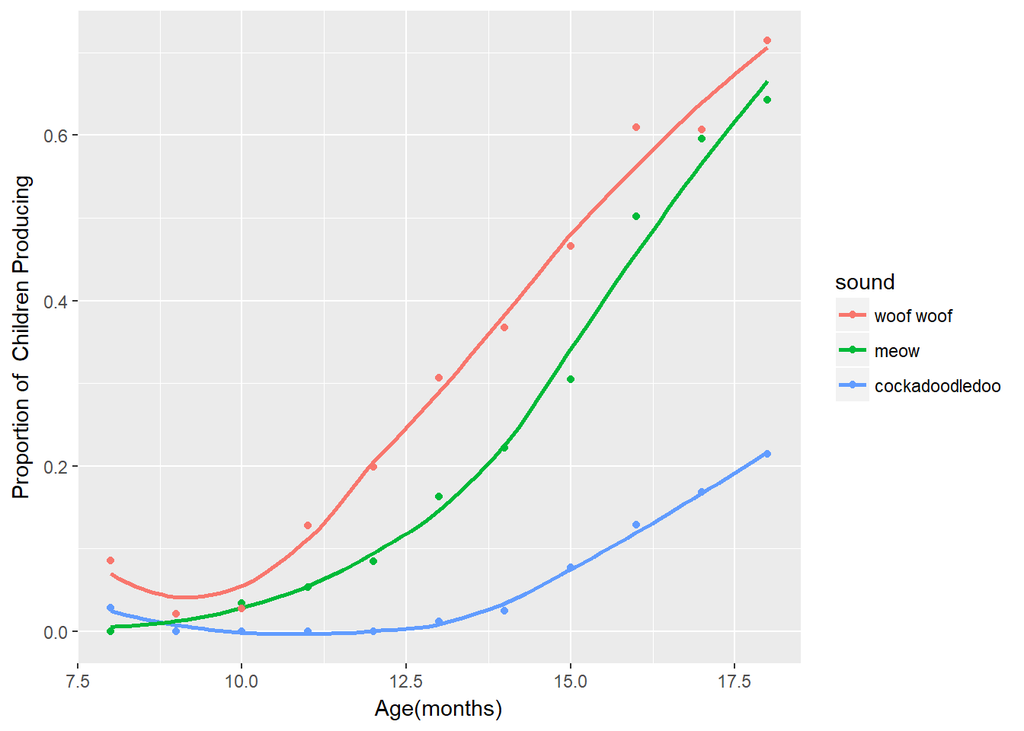

```r
sound_traj + scale_color_hue()
```

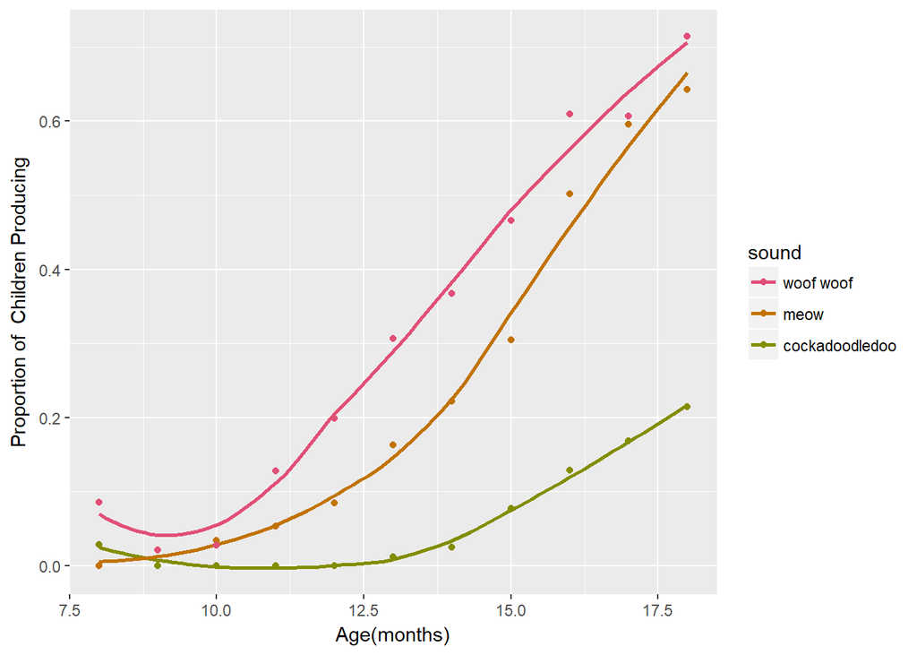

```r
sound_traj +  scale_color_hue(h = c(0, 90), l = 55, c = 100)
```

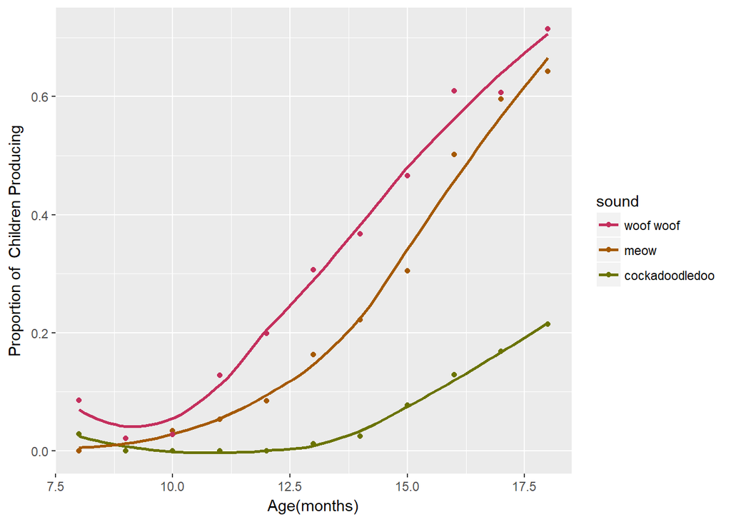

```r
sound_traj +  scale_color_hue(h = c(0, 90), l = 45, c = 100)
```

*Challenge #5*

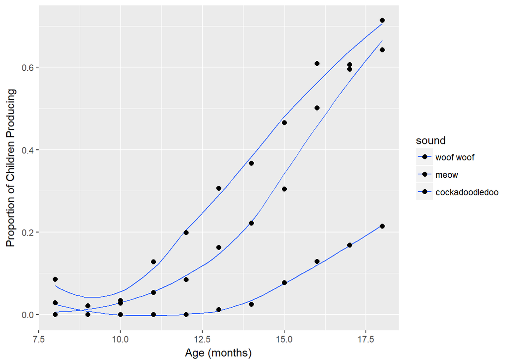

```r
ggplot(anim, aes(x = age,
                         y = prop_produce,
                         fill = fct_reorder2(sound, age, prop_produce))) +
  geom_smooth(se = FALSE, lwd = .5) +
  geom_point(size = 2) +
  labs(x = "Age (months)",
       y = "Proportion of Children Producing",
       fill = "sound") +
  scale_fill_manual(values = c("cornflowerblue",
                               "seagreen", "coral"))
```

*Challenge #6*

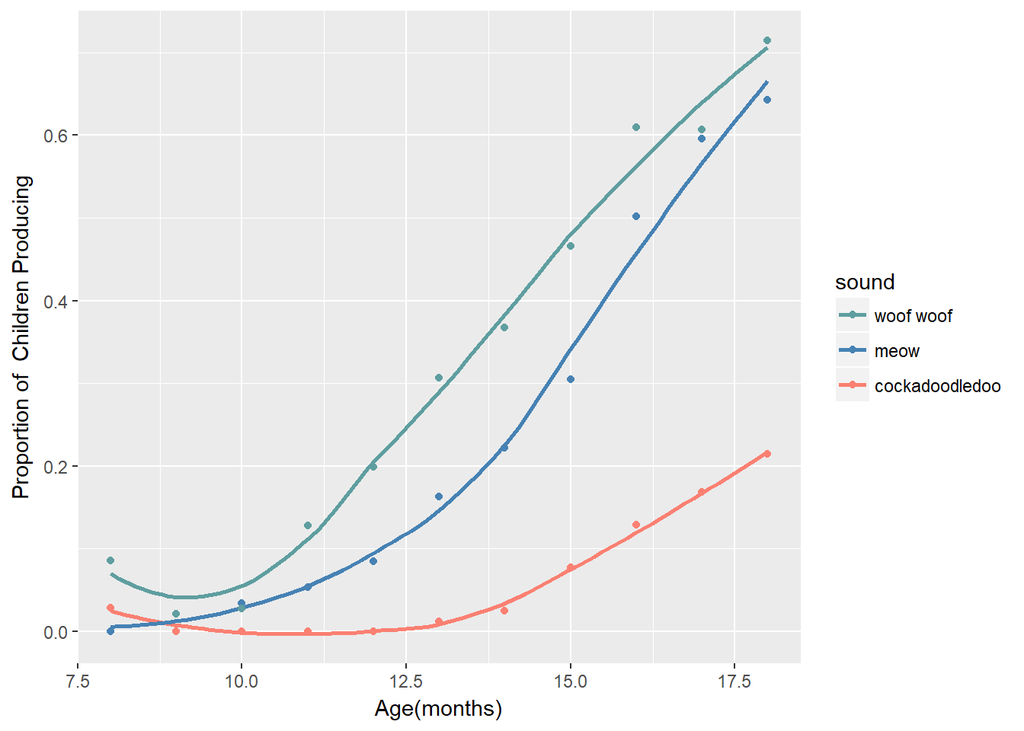

```r
my_colors <- c("cadetblue", "steelblue", "salmon") # quote color names
sound_traj +
  scale_color_manual(values = my_colors) # note: not in quotes
```

*Challenge #7*

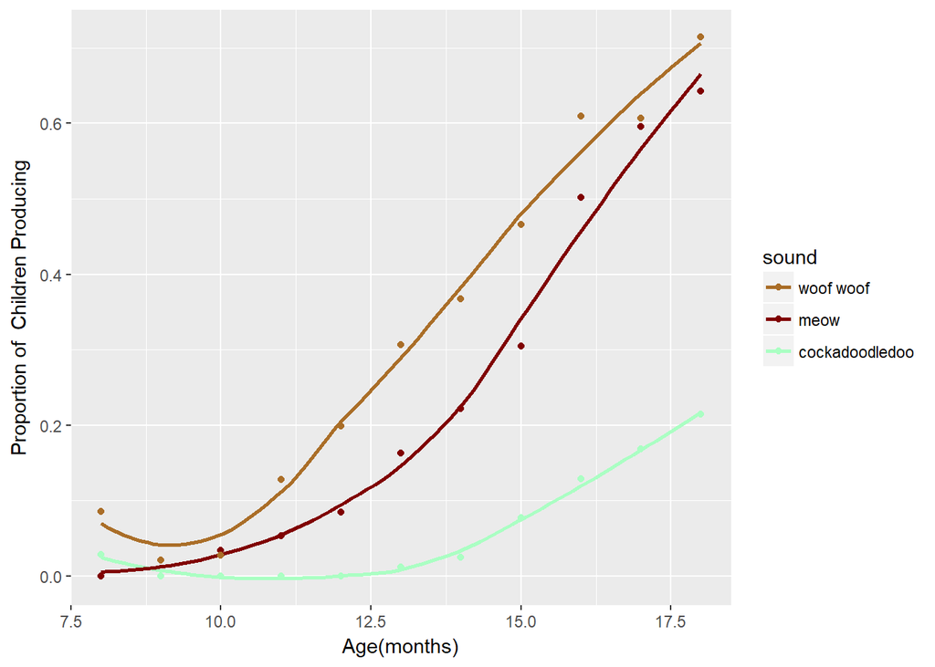

```r
colors<-c("#aa6e28","#800000","#aaffc3","#808000","#008080","#000080")
sound_traj +
  scale_colour_manual(values = colors )
```

*Challenge #8*

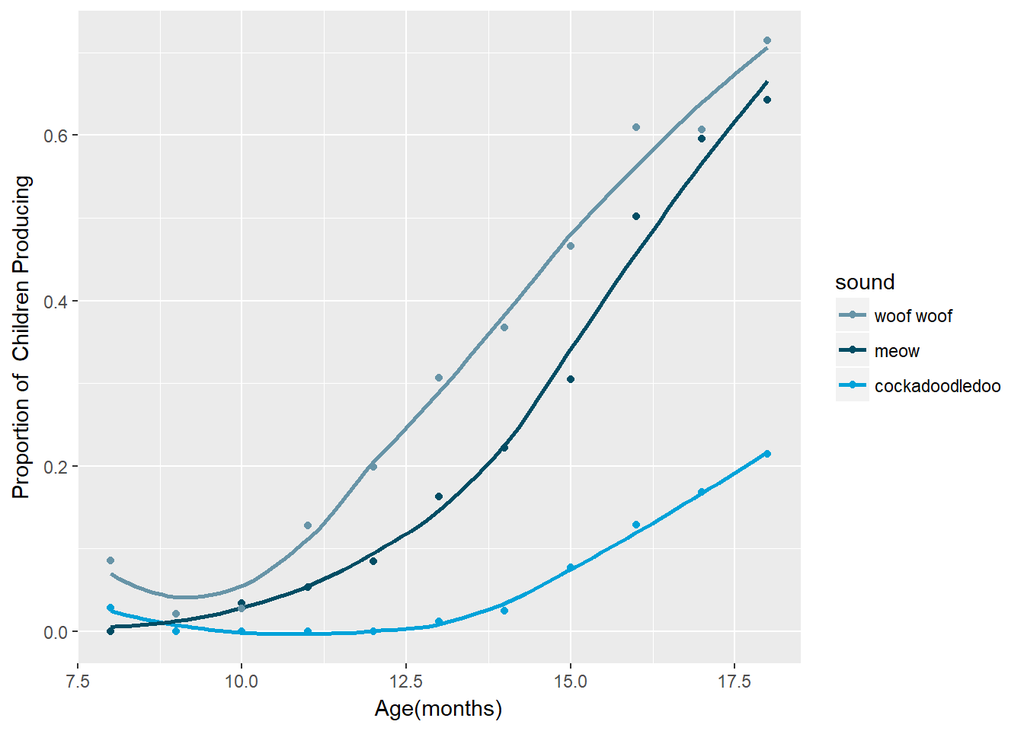

```r
library(ggthemes)
sound_traj +
  scale_color_economist()
```

*Challenge #9*

```r
library(viridis)
```

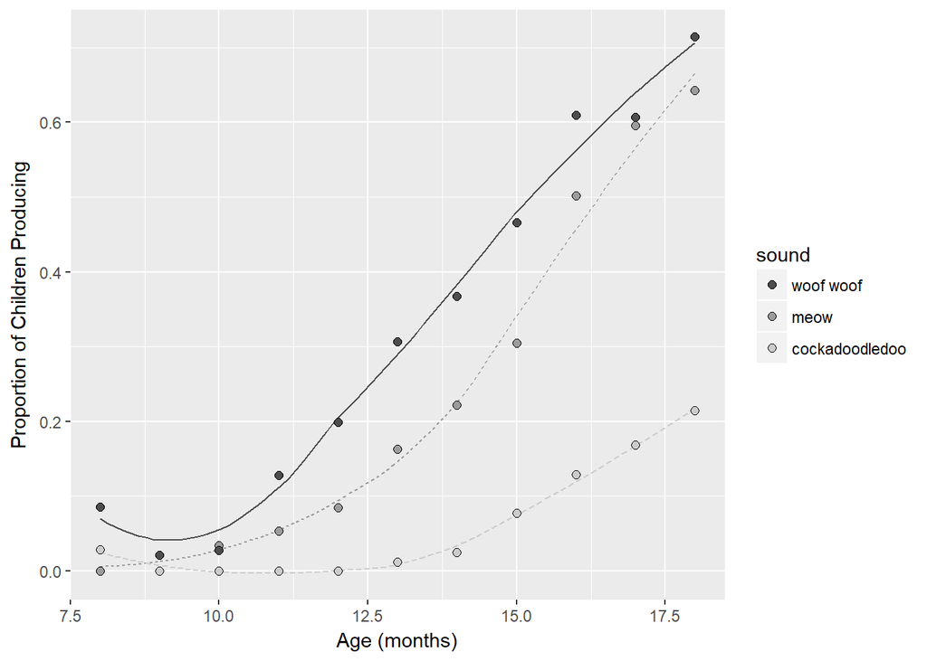

```r
ggplot(anim, aes(x = age,
                   y = prop_produce,
                   fill = fct_reorder2(sound, age, prop_produce))) +
  geom_smooth(aes(color = fct_reorder2(sound, age, prop_produce),
                  lty = fct_reorder2(sound, age, prop_produce)),
              se = FALSE, lwd = .5, show.legend = FALSE) +
  geom_point(size = 2, shape = 21) +
  labs(x = "Age (months)",
       y = "Proportion of Children Producing",
       fill = "sound") +
  scale_fill_grey(start = 0.3, end = .8) +
  scale_color_grey(start = 0.3, end = .8)
```

*Challenge #10*

```r
#Dataset taken from first lab
library(babynames)
alison <- babynames %>%
  filter(name == "Alison" | name == "Allison") %>%
  filter(sex == "F") %>%
  filter(year > 1950) %>%
  filter(year < 2000)
library(wesanderson)
```

```r
first_plot <- ggplot(alison, aes(x = year,  y = prop ,color=fct_reorder2(name,year,prop))) +
  geom_point()+
  geom_line() +
  labs(x = "Year", y = "Proportion of female population",color="Category")
```

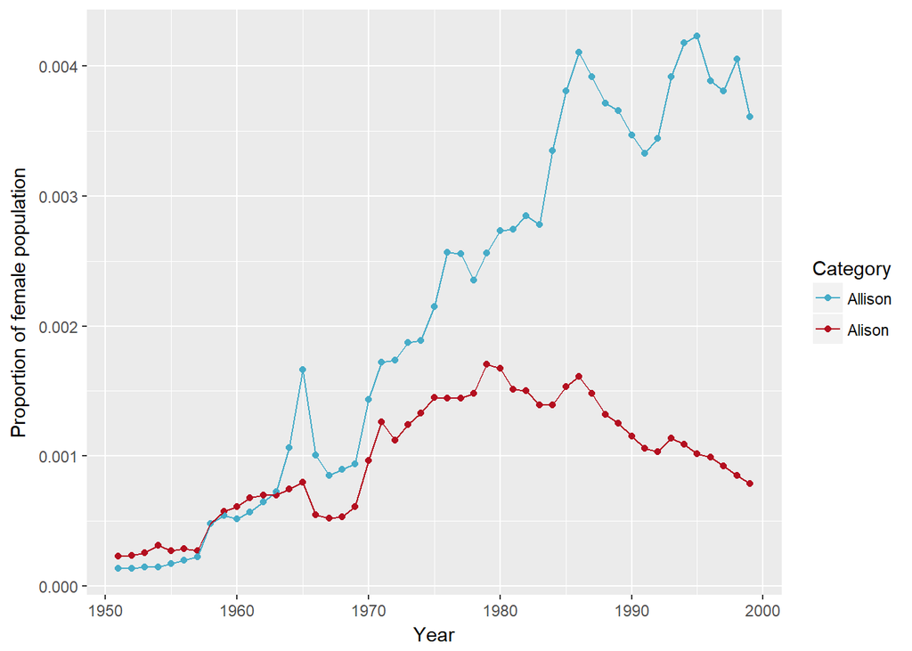

```r
first_plot + scale_color_manual(values=wes_palette("FantasticFox1")[c(3,5)])
```

*2. Second plot shows the same plot in greyscale version*

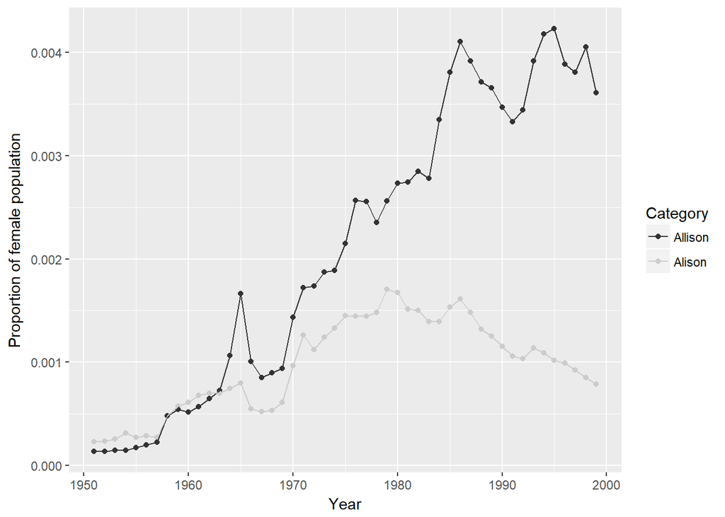

```r
first_plot + scale_color_grey(start = 0.2, end = .8)
```

*3. In the third plot,t he worst color combination is apparent thus making it difficult to distinguish between the categories especially close to the 1960 value and making the data values seem to be the same.The color combinations used are“#672d2d”,“#47193b”,“#3d492b”*

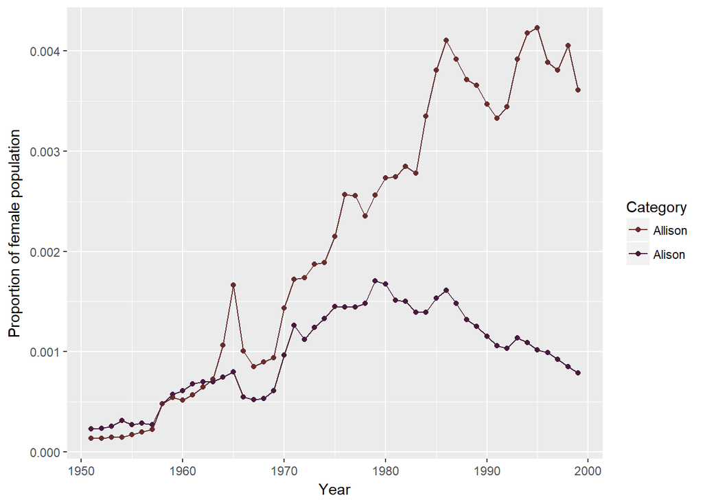

```r
first_plot+scale_color_manual(values=c("#672d2d","#47193b","#3d492b"))
```